# Глава_11_Экзамен

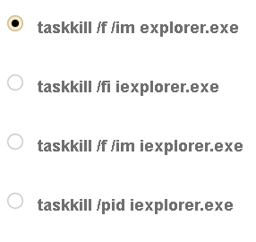

ИТ-отдел только что купил 15 беспроводных точек доступа для обеспечения полного беспроводного покрытия для всех 100 сотрудников в пределах компании и хочет развернуть наиболее защищенное и масштабируемое беспроводное сетевое решение. Какой метод аутентификации с открытым исходным кодом должен выполнять аутентификацию от имени всех 15 устройств беспроводной сети?

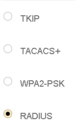

Пользователь пытается получить доступ к общедоступному принтеру, подключенному к ПК с ОС Windows 10, но не может это сделать. Какую учетную запись для этого необходимо использовать?

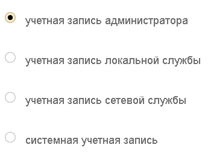

Пользователь ПК с ОС Windows 10 хочет автоматически синхронизировать профиль пользователя с различными устройствами, работающими под управлением Windows 10, которыми владеет этот пользователь. Как пользователь может это делать?

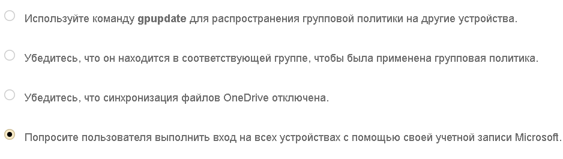

Технический специалист хочет подготовить режим аварийного восстановления для компьютеров в сети. Сеть включает в себя различные настольные компьютеры и ноутбуки различных производителей. Все компьютеры работают под управлением 32- или 64-разрядной версии ОС Windows 10 Pro. Как технический специалист должен подготовить носитель для восстановления системы?

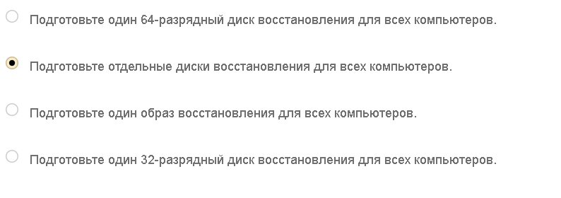

Пользователь в корпоративной среде сообщает, что после обновления Windows компьютер с ОС Windows, используемый сотрудниками по совместительству, медленно работает. Что должен сделать технический специалист в этой ситуации? (Выберите два варианта.)

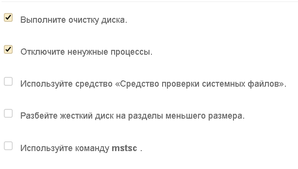

Технический специалист выполняет диагностику ПК с ОС Windows 10, процедура запуска которого выполняется очень медленно. Ему нужно выяснить, какие приложения пользователя вызывают наибольшую задержку при запуске ПК. Какой инструмент для этого необходимо использовать?

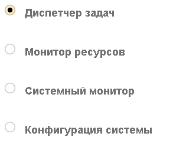

Технический специалист изменяет длину локального пароля пользователя до пяти символов, используя оснастку «Локальная политика безопасности». Технический специалист пытается создать пароль «dave» для учетной записи локального пользователя «dave», но это не удается, так как не соблюдаются требования к сложности пароля для ОС Windows 10. Какой пароль будет соответствовать требованиям?

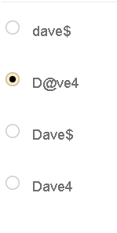

Пользователю нужно отобразить список текущих процессов, выполняющихся на локальном или удаленном компьютере. Какую команду Windows ему лучше всего использовать для этого?

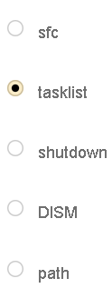

IT Essentials (Версия 7.00) - Промежуточный экзамен по главам 10-11 курса ITE 7.0. Дата сдачи экзамена: 08/19/2021 03:49 PM GMT+0300 Знания в конкретной области - стандартный балл Макс. кол-во баллов: 24

Заработанные баллы: 22

Процентное отношение: 91,7%

На основании ваших ответов на вопросы экзамена вы получили следующие рекомендации:

Индивидуальная обратная связь Обратная связь по теме Обратите внимание, что по некоторым вопросам рекомендации могут быть недоступны.

Программное обеспечение. Windows. Панели управления Макс. кол-во баллов: 4

Заработанные баллы: 4

Процентное отношение: 100%

Программное обеспечение. Windows. Системы Макс. кол-во баллов: 2

Заработанные баллы: 2

Процентное отношение: 100%

Безопасность. Управление. Защита ресурсов Макс. кол-во баллов: 2

Заработанные баллы: 2

Процентное отношение: 100%

Программное обеспечение. Windows. Интерфейс командной строки Макс. кол-во баллов: 6

Заработанные баллы: 4

Процентное отношение: 66,7%

Процентное отношение: 100%

Программное обеспечение. ОС компьютера. Требования Макс. кол-во баллов: 0

Заработанные баллы: 0

Процентное отношение: 0,0%

Программное обеспечение. Windows. Управление Макс. кол-во баллов: 2

Заработанные баллы: 2

Процентное отношение: 100%

Программное обеспечение. Windows. Возможности подключения Макс. кол-во баллов: 2

Заработанные баллы: 2

Процентное отношение: 100%

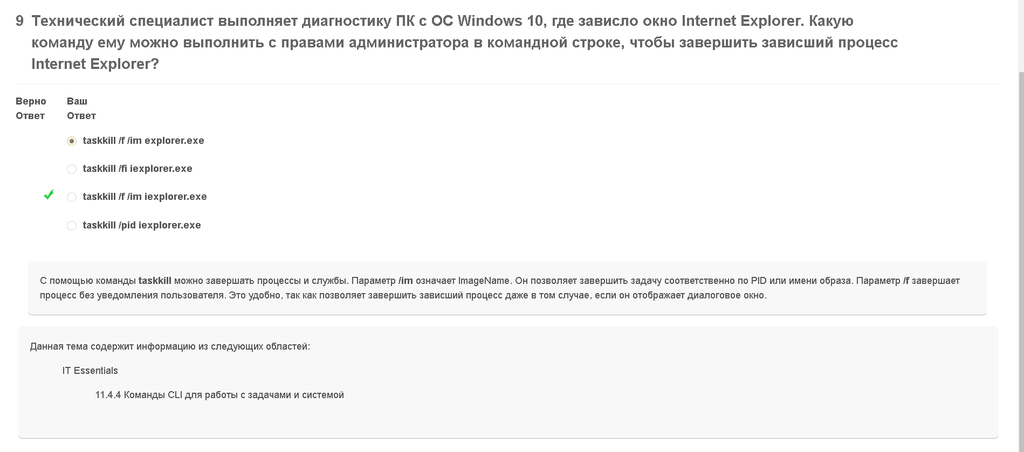